# 成為初級資料分析師 | Python 機器學習

> 分類（Classification）

## 郭耀仁

## 大綱

- 端到端的分類問題
- 未經過訓練的分類器（Dummy classifiers）
- 簡單貝氏分類器（Naive Bayes Classifier）
- 羅吉斯回歸分類器（Logistic Regression Classifier）
- 決策樹分類器（Decision Tree Classifier）
- 隨機森林分類器（Random Forest Classifier）
- 二元至多元（One vs. All）
- 不同的分類模型評估指標

## 端到端的分類問題

## [Titanic](https://www.kaggle.com/c/titanic)

```python
import pandas as pd
from sklearn.model_selection import train_test_split
from sklearn.linear_model import LogisticRegression
from sklearn.metrics import accuracy_score

titanic = pd.read_csv("https://storage.googleapis.com/kaggle_datasets/Titanic-Machine-Learning-from-Disaster/train.csv")
X = titanic["Pclass"].values.reshape(-1, 1)
y = titanic["Survived"].values
X_train, X_validation, y_train, y_validation = train_test_split(X, y, test_size=0.33, random_state=42)
lr = LogisticRegression(solver='lbfgs')
lr.fit(X_train, y_train)
y_pred = lr.predict(X_validation)
acc = accuracy_score(y_validation, y_pred)
print("Accuracy: {:.2f}%".format(acc*100))
```

```
Accuracy: 69.83%
```

## 試著將 $X$ 替換為 `Age` 變數

```python
X = titanic["Age"].values.reshape(-1, 1)
y = titanic["Survived"].values
X_train, X_validation, y_train, y_validation = train_test_split(X, y, test_size=0.33, random_state=42)
lr = LogisticRegression(solver='lbfgs')
#lr.fit(X_train, y_train) # ValueError: Input contains NaN, infinity or a value too large for dtype('float64').
```

## 使用 `np.isnan()` 偵測遺漏值個數

```python
import numpy as np

n_nan = np.isnan(X).sum()
print(n_nan)
```

```
177
```

## 以 `np.where()` 進行簡單遺漏值填補

```python
import numpy as np

X_mean = np.nanmean(X)
X_imputed_by_mean = np.where(np.isnan(X), X_mean, X)
n_nan = np.isnan(X_imputed_by_mean).sum()
print(X_mean)
print(n_nan)
```

```
29.69911764705882
0
```

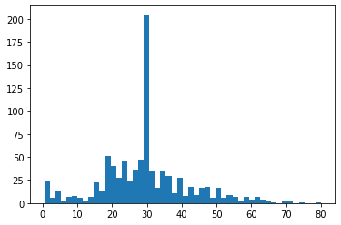

```python
%matplotlib inline
import matplotlib.pyplot as plt

plt.hist(X_imputed_by_mean, bins=50)
plt.show()
```

## 以 `sklearn.impute.SimpleImputer()` 進行簡單遺漏值填補

```python
from sklearn.impute import SimpleImputer

mean_imputer = SimpleImputer(missing_values=np.nan, strategy='mean')
X_imputed_by_mean = mean_imputer.fit_transform(X)
n_nan = np.isnan(X_imputed_by_mean).sum()
print(n_nan)
```

```
0
```

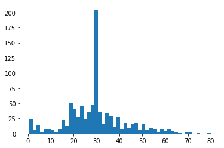

```python
import matplotlib.pyplot as plt

plt.hist(X_imputed_by_mean, bins=50)
plt.show()
```

## 隨堂練習：以 `np.where()` 與 `sklearn.impute.SimpleImputer()` 進行中位數填補

```python
print(X_median)
print(n_nan)
```

```
28.0
0
```

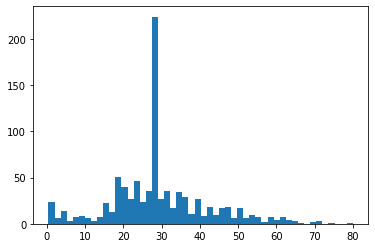

```python
import matplotlib.pyplot as plt

plt.hist(X_imputed_by_median, bins=50)
plt.show()
```

## 以 `df.map()` 進行簡單遺漏值填補

```python
import pandas as pd

df = titanic[["Pclass", "Age"]]
grouped = df.groupby("Pclass")
age_mean_by_pclass = dict(grouped["Age"].mean())
nan_indices = np.where(np.isnan(df["Age"].values))[0]
imputed_ages = df.iloc[nan_indices, :]["Pclass"].map(age_mean_by_pclass).values.copy()
original_age = df["Age"].values.copy()
original_age[nan_indices] = imputed_ages
df = df.assign(Age_Imputed=original_age)
print(age_mean_by_pclass)
df[df["Age"].isna()].head(7)
```

```
{1: 38.233440860215055, 2: 29.87763005780347, 3: 25.14061971830986}
```

|  | Pclass | Age | Age_Imputed |
| --- | --- | --- | --- |
| 5 | 3 | NaN | 25.140620 |
| 17 | 2 | NaN | 29.877630 |
| 19 | 3 | NaN | 25.140620 |
| 26 | 3 | NaN | 25.140620 |
| 28 | 3 | NaN | 25.140620 |
| 29 | 3 | NaN | 25.140620 |
| 31 | 1 | NaN | 38.233441 |

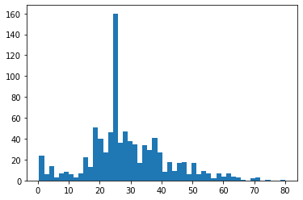

```python
import matplotlib.pyplot as plt

plt.hist(df["Age_Imputed"], bins=50)
plt.show()
```

## 未經過訓練的分類器（Dummy classifiers）

## 未經過訓練的分類器

> 使用簡單守則對資料進行分類，像是許多的 `if` 條件式

## 常見未經過訓練的分類器

- 硬幣
- 專家意見
- ...etc.

## 投擲硬幣來分類 [Titanic](https://www.kaggle.com/c/titanic) 乘客的生死

```python
import pandas as pd
from sklearn.model_selection import train_test_split

titanic = pd.read_csv("https://storage.googleapis.com/kaggle_datasets/Titanic-Machine-Learning-from-Disaster/train.csv")
y = titanic["Survived"].values
y_train, y_validation = train_test_split(y, test_size=0.33, random_state=42)
```

```python
from random import sample

y_pred = [sample([0, 1], k=1)[0] for _ in range(y_validation.size)]
y_pred = np.array(y_pred)
print(y_pred)
```

```
[1 0 1 0 1 1 1 1 0 1 0 0 0 1 1 1 0 0 0 0 0 1 0 1 1 1 0 1 0 0 1 1 0 1 0 0 0
 1 0 0 1 1 1 0 1 1 0 0 0 1 1 0 1 1 0 1 1 0 1 1 1 0 0 0 0 0 1 0 1 1 1 1 0 1
 0 1 1 0 0 1 1 0 0 0 1 0 1 1 1 1 1 1 1 0 1 0 1 0 1 1 0 0 1 1 1 1 1 1 0 0 1
 1 1 1 1 1 1 0 0 1 1 0 0 1 0 0 1 1 0 0 0 0 1 1 0 1 1 1 0 1 1 1 1 0 0 0 1 1
 0 1 0 1 0 0 1 0 0 1 0 0 0 0 1 1 0 1 1 1 0 0 1 1 1 0 0 0 0 1 1 0 0 1 0 0 1
 0 0 1 1 1 1 0 0 0 0 1 1 0 0 1 0 1 1 1 0 0 0 0 1 1 0 0 1 1 0 1 1 1 0 1 0 0
 1 0 0 1 1 1 1 0 1 0 1 0 0 1 0 0 0 0 1 0 0 1 0 1 0 1 1 0 1 0 1 0 0 1 0 1 0
 1 0 0 0 1 1 0 1 0 1 1 0 1 0 0 1 0 0 1 1 0 1 1 0 1 1 0 0 1 1 0 0 0 0 0 1]
```

## 投擲硬幣分類 [Titanic](https://www.kaggle.com/c/titanic) 乘客的生死準不準？

[figure not shown]

Source: https://en.wikipedia.org/wiki/Confusion_matrix

```python
n_tp_tn = (y_pred == y_validation).sum()
n_validations = y_validation.size
print("Accuracy score: {:.2f}%".format(n_tp_tn*100/n_validations))
```

```
Accuracy score: 49.83%
```

## 隨堂練習：投擲硬幣來分類球員是前場（Forward/Center）或後場（Guard）

```python
import numpy as np
import pandas as pd
from sklearn.model_selection import train_test_split

pos_map_dict = {
    'G': 0,
    'F': 1,
    'C': 1,
    'G-F': 0,
    'F-C': 1,
    'C-F': 1,
    'F-G': 1
}

nba_players = pd.read_csv("https://kaggle-getting-started.s3-ap-northeast-1.amazonaws.com/regression/nba_players.csv")
nba_players["pos_recategorized"] = nba_players["pos"].map(pos_map_dict)
y = nba_players["pos_recategorized"].values
y_train, y_validation = train_test_split(y, test_size=0.33, random_state=42)
```

```python
print("Accuracy score: {:.2f}%".format(acc*100))
```

```
Accuracy score: 46.05%
```

## 聽聞專家意見分類 [Titanic](https://www.kaggle.com/c/titanic) 乘客的生死

> Although there was some element of luck involved in surviving the sinking, some groups of people were more likely to survive than others, such as women, children, and the upper-class.

```python
import pandas as pd
from sklearn.model_selection import train_test_split
from sklearn.impute import SimpleImputer

titanic = pd.read_csv("https://storage.googleapis.com/kaggle_datasets/Titanic-Machine-Learning-from-Disaster/train.csv")
subset = titanic[["Sex", "Age", "Pclass"]]
median_imputer = SimpleImputer(missing_values=np.nan, strategy='median')
age_imputed = median_imputer.fit_transform(subset["Age"].values.reshape(-1, 1))
subset = subset.assign(Age = age_imputed)
X = subset.values
y = titanic["Survived"].values
X_train, X_validation, y_train, y_validation = train_test_split(X, y, test_size=0.33, random_state=42)
```

```python
import numpy as np

def expert_opinion(X):
    if X[0] == 'female' or X[1] < 12 or X[2] == 1:
        return 1
    else:
        return 0

y_pred = np.zeros(y_validation.size, dtype=int)
for i in range(X_validation.shape[0]):
    y_pred[i] = expert_opinion(X_validation[i])
```

## 聽聞專家意見分類 [Titanic](https://www.kaggle.com/c/titanic) 乘客的生死準不準？

```python
n_tp_tn = (y_pred == y_validation).sum()
n_validations = y_validation.size
print("Accuracy score: {:.2f}%".format(n_tp_tn*100/n_validations))
```

```
Accuracy score: 78.31%
```

## 隨堂練習：聽聞專家意見預測來分類球員是前場（Forward/Center）或後場（Guard）

> 前場球員身高普遍比後場球員高

```python
import numpy as np
import pandas as pd
from sklearn.model_selection import train_test_split

pos_map_dict = {
    'G': 0,
    'F': 1,
    'C': 1,
    'G-F': 0,
    'F-C': 1,
    'C-F': 1,
    'F-G': 1
}

nba_players = pd.read_csv("https://kaggle-getting-started.s3-ap-northeast-1.amazonaws.com/regression/nba_players.csv")
nba_players["pos_recategorized"] = nba_players["pos"].map(pos_map_dict)
X = nba_players["heightMeters"].values.reshape(-1, 1)
y = nba_players["pos_recategorized"].values
X_train, X_validation, y_train, y_validation = train_test_split(X, y, test_size=0.33, random_state=42)
```

```python
print("Accuracy score: {:.2f}%".format(acc*100))
```

```
Accuracy score: 88.16%
```

## 分類模型的 E, T, 與 P

> A computer program is said to learn from experience E with respect to some class of tasks T and performance measure P if its performance at tasks in T, as measured by P, improves with experience E.

> Tom Mitchel

## E: Experience

NBA 球員的身高

## T: Task

依據一名球員的身高預測他在球場上的位置

```python
import numpy as np

X_test = np.array([1.98]).reshape(-1, 1) # 一位身高 198 cm 的球員
X_test = np.array([1.83]).reshape(-1, 1) # 一位身高 183 cm 的球員
```

## P: Performance

- 跟 $f$ 長得很像的 $h$，分類與後來在球場上的位置相同
- 跟 $f$ 長得不太像的 $h$，分類與後來在球場上的位置不相同

## 分類模型 in short

建立一個輸入向量 $x$ 能夠得到純量 $\hat{y}$ 輸入的系統 $h$，其中向量 $w$ 稱為是系統的參數、$\hat{y}$ 則是一個離散值，經由某些函數（$g$）將 $h$ 轉換而得

$$ \hat{y} = g(h(x)) = g(w^Tx) \\ \hat{y} = g(h(X)) = g(Xw) \\ $$

## 使用誤分類數評估 $h$ 跟 $f$ 的相似程度

$$J(h)_{test} = \sum^{n_{test}}\delta (\hat{y} \neq y_{test})$$

## 簡單貝氏分類器（Naive Bayes Classifier）

## 如何從連續型的輸出 $Xw$ 到離散型的輸出 $\hat{y}$

$$ \hat{y} = g(h(X)) = H(\sigma(Xw)) $$

## 其中 $\sigma$ 俗稱為激勵函數（Activation function），$H$ 稱為階躍函數（Step function）

- 激勵函數將連續型輸出轉換為機率
- 階躍函數將機率輸出轉換為離散值

## 分類器的輸出亦可以機率表示：給定 $x$ 其類別為 $C_i$ 的機率為何

$$ \sigma(x^Tw) = P(C_i | x) $$

## 隨堂練習：製作一副撲克牌

```python
suits = ["Spade", "Heart", "Diamond", "Club"]
ranks = [str(i) for i in range(1, 11)] + ["Jack", "Queen", "King"]
```

```python
print(cards)
```

```
['Spade 1', 'Spade 2', 'Spade 3', 'Spade 4', 'Spade 5', 'Spade 6', 'Spade 7', 'Spade 8', 'Spade 9', 'Spade 10', 'Spade Jack', 'Spade Queen', 'Spade King', 'Heart 1', 'Heart 2', 'Heart 3', 'Heart 4', 'Heart 5', 'Heart 6', 'Heart 7', 'Heart 8', 'Heart 9', 'Heart 10', 'Heart Jack', 'Heart Queen', 'Hear…
```

## 現在有一張撲克牌覆蓋在桌面上，它是 Jack、Queen 或 King 的機率是多少？

$$ P(Face) = \frac{12}{52} $$

## 隨堂練習：現在有 52 張撲克牌覆蓋在桌面上，請以 1 代表 Jack、Queen 或 King；以 0 代表其他撲克牌對這 52 張牌進行二元分類

```python
print(y_pred)
```

```
[0 0 1 0 1 1 0 0 0 0 0 1 0 0 0 0 0 1 0 0 0 0 0 0 0 1 0 1 0 0 0 0 0 0 0 0 0
 1 0 1 1 0 1 0 0 0 0 1 0 0 0 0]
```

```python
card_df.head()
```

|  | card | y_true | y_pred |
| --- | --- | --- | --- |
| 19 | Heart 7 | 0 | 0 |
| 41 | Club 3 | 0 | 0 |
| 47 | Club 9 | 0 | 1 |
| 12 | Spade King | 1 | 0 |
| 43 | Club 5 | 0 | 1 |

```python
y_true = card_df["y_true"].values
y_pred = card_df["y_pred"].values
n_tp_tn = (y_true == y_pred).sum()
acc = n_tp_tn / y_true.size
print("Accuracy score: {:.2f}%".format(acc*100))
```

```
Accuracy score: 73.08%
```

## 以上都跟「貝氏」沒有關係

## 現在有一張已知是 Jack、Queen 或 King 的撲克牌覆蓋在桌面上，它是 King 的機率是多少？

$$ P(King|Face) = \frac{4}{12} $$

## 根據貝氏定理回答

$$ P(King|Face) = \frac{P(Face|King) \times P(King)}{P(Face)} = \frac{1 \times \frac{4}{52}}{\frac{12}{52}} $$

## 貝氏定理

$$ P(C_i|x) = \frac{P(x|C_i)P(C_i)}{P(x)} $$

其中 $P(C_i|x)$ 即我們俗稱的後驗機率（Posterior Probability）

## Monty Hall Problem

> Suppose you're on a game show, and you're given the choice of three doors: Behind one door is a car; behind the others, goats. You pick a door, say No. 1, and the host, who knows what's behind the doors, opens another door, say No. 3, which has a goat. He then says to you, "Do you want to pick door No. 2?" Is it to your advantage to switch your choice?

Source: https://en.wikipedia.org/wiki/Monty_Hall_problem

[figure not shown]

Source: https://en.wikipedia.org/wiki/Monty_Hall_problem

[figure not shown]

Source: https://www.youtube.com

## 事件的代號

$$ C_i: \text{車子在第 i 扇門} \\ H_i: \text{主持人開第 i 扇門} \\ X_i: \text{觀眾選第 i 扇門} $$

## 計算這兩個機率，然後決定是否要從 $X_1$ 更換至 $X_2$

$$ P(C_1|H_3, X_1) = ? \\ P(C_2|H_3, X_1) = ? $$

$$ P(C_1|H_3, X_1) = \frac{P(C_1, H_3, X_1)}{P(H_3, X_1)} = \frac{P(H_3|C_1, X_1)P(C_1, X_1)}{P(H_3, X_1)} = \frac{\frac{1}{2} \times P(C_1, X_1)}{P(H_3) \times P(X_1)} = \frac{\frac{1}{2} \times P(C_1) \times P(X_1)}{P(H_3) \times 1} = \frac{\frac{1}{2} \times \frac{1}{3}}{\frac{1}{2}} = \frac{1}{3} \\ P(C_2|H_3, X_1) = \frac{P(C_2, H_3, X_1)}{P(H_3, X_1)} = \frac{P(H_3|C_2, X_1)P(C_2, X_1)}{P(H_3, X_1)} = \frac{1 \times P(C_2, X_1)}{P(H_3) \times P(X_1)} = \frac{1 \times P(C_2) \times P(X_1)}{P(H_3) \times 1} = \frac{\frac{1}{3}}{\frac{1}{2}} = \frac{2}{3} $$

## 使用簡單貝氏分類器分類乘客的生存與否

```python
import pandas as pd

titanic = pd.read_csv("https://storage.googleapis.com/kaggle_datasets/Titanic-Machine-Learning-from-Disaster/train.csv")
titanic_subset = titanic[["Pclass", "Survived"]]
titanic_subset.head()
```

|  | Pclass | Survived |
| --- | --- | --- |
| 0 | 3 | 0 |
| 1 | 1 | 1 |
| 2 | 3 | 1 |
| 3 | 1 | 1 |
| 4 | 3 | 0 |

## 使用 `pd.crosstab()` 製作 Frequency Table

```python
freq_table = pd.crosstab(index=titanic_subset["Survived"], columns=titanic_subset["Pclass"])
freq_table
```

| Pclass Survived | 1 | 2 | 3 |
| --- | --- | --- | --- |
| 0 | 80 | 97 | 372 |
| 1 | 136 | 87 | 119 |

## 隨堂練習：計算後驗機率

$$ P(Survived | Pclass = 1) = \frac{P(Pclass = 1 | Survived) \times P(Survived)}{P(Pclass = 1)} \\ P(Survived | Pclass = 2) = \frac{P(Pclass = 2 | Survived) \times P(Survived)}{P(Pclass = 2)} \\ P(Survived | Pclass = 3) = \frac{P(Pclass = 3 | Survived) \times P(Survived)}{P(Pclass = 3)} \\ $$

```python
print(p_Survived_Pclass_1)
print(p_Survived_Pclass_2)
print(p_Survived_Pclass_3)
```

```
0.24167601945379721
0.1814888010540184
0.09302804007488324
```

## 如何操作簡單貝氏分類器來預測乘客的生存與否

```python
import pandas as pd
from sklearn.model_selection import train_test_split

titanic = pd.read_csv("https://storage.googleapis.com/kaggle_datasets/Titanic-Machine-Learning-from-Disaster/train.csv")
X = titanic["Pclass"].values.reshape(-1, 1)
y = titanic["Survived"].values
X_train, X_validation, y_train, y_validation = train_test_split(X, y, test_size=0.33, random_state=42)
```

## 製作訓練資料的 Frequency Table

```python
train_df = pd.DataFrame()
train_df["Pclass"] = X_train.ravel()
train_df["Survived"] = y_train
freq_table = pd.crosstab(index=train_df["Survived"], columns=train_df["Pclass"])
freq_table
```

| Pclass Survived | 1 | 2 | 3 |
| --- | --- | --- | --- |
| 0 | 55 | 64 | 255 |
| 1 | 80 | 61 | 81 |

## 隨堂練習：計算訓練資料的後驗機率

```python
print(p_Survived_Pclass_1)
print(p_Survived_Pclass_2)
print(p_Survived_Pclass_3)
```

```
0.22073079791200598
0.18177181208053694
0.08979506232023012
```

## 隨堂練習：將後驗機率應用至 $X_{validation}$，得到 $\hat{y}$

```python
y_pred = get_y_pred(X_validation, p_Survived_Pclass_1, p_Survived_Pclass_2, p_Survived_Pclass_3)
n_tp_tn = (y_pred == y_validation).sum()
n_validations = y_validation.size
acc = n_tp_tn / n_validations
print("Accuracy score: {:.2f}%".format(acc*100))
```

```
Accuracy score: 57.97%
```

## 如果簡單貝氏分類器希望納入多個類別變數呢？

```python
import pandas as pd
from sklearn.model_selection import train_test_split

titanic = pd.read_csv("https://storage.googleapis.com/kaggle_datasets/Titanic-Machine-Learning-from-Disaster/train.csv")
X = titanic[["Pclass", "Sex"]].values
y = titanic["Survived"].values
X_train, X_validation, y_train, y_validation = train_test_split(X, y, test_size=0.33, random_state=42)
```

## 製作訓練資料的 Frequency Table

```python
train_df = pd.DataFrame()
train_df["Pclass"] = X_train[:, 0].ravel()
train_df["Sex"] = X_train[:, 1].ravel()
train_df["Survived"] = y_train
freq_table = pd.crosstab(index=train_df["Survived"], columns=[train_df["Pclass"], train_df["Sex"]])
freq_table
```

| Pclass Sex Survived | 1 female | 1 male | 2 female | 2 male | 3 female | 3 male |
| --- | --- | --- | --- | --- | --- | --- |
| 0 | 3 | 52 | 1 | 63 | 53 | 202 |
| 1 | 56 | 24 | 47 | 14 | 46 | 35 |

## 計算有 n 個特徵的後驗機率（泛化形式）

$$ P(C_i|x_0, x_1, ..., x_n) \propto P(x_0, x_1, ..., x_n|C_i)P(C_i) \propto P(C_i) \prod_{j=1}^n P(x_j|C_i) $$

## 計算訓練資料的後驗機率

$$ P(Survived|Pclass=1, Sex=female) = P(Survived) \times \frac{P(Pclass=1|Survived)}{P(Survived)} \times \frac{P(female|Survived)}{P(Survived)}\\ P(Survived|Pclass=1, Sex=male) = P(Survived) \times \frac{P(Pclass=1|Survived)}{P(Survived)} \times \frac{P(male|Survived)}{P(Survived)}\\ P(Survived|Pclass=2, Sex=female) = P(Survived) \times \frac{P(Pclass=2|Survived)}{P(Survived)} \times \frac{P(female|Survived)}{P(Survived)} $$

## 計算訓練資料的後驗機率（cont'd）

$$ P(Survived|Pclass=2, Sex=male) = P(Survived) \times \frac{P(Pclass=2|Survived)}{P(Survived)} \times \frac{P(male|Survived)}{P(Survived)}\\ P(Survived|Pclass=3, Sex=female) = P(Survived) \times \frac{P(Pclass=3|Survived)}{P(Survived)} \times \frac{P(female|Survived)}{P(Survived)}\\ P(Survived|Pclass=3, Sex=male) = P(Survived) \times \frac{P(Pclass=3|Survived)}{P(Survived)} \times \frac{P(male|Survived)}{P(Survived)}\\ $$

```python
n_passengers = freq_table.sum().sum()
n_survived = freq_table.loc[1, :].sum()
n_Pclass1_survived = freq_table.loc[1, 1].sum()
n_Pclass2_survived = freq_table.loc[1, 2].sum()
n_Pclass3_survived = freq_table.loc[1, 3].sum()
n_female_survived = freq_table.loc[1, :].loc[:, "female"].sum()
n_male_survived = freq_table.loc[1, :].loc[:, "male"].sum()
```

```python
p_survived = n_survived / n_passengers
p_Pclass1_survived = n_Pclass1_survived / n_survived
p_Pclass2_survived = n_Pclass2_survived / n_survived
p_Pclass3_survived = n_Pclass3_survived / n_survived
p_female_survived = n_female_survived / n_survived
p_male_survived = n_male_survived / n_survived
```

```python
p_survived_Pclass1_female = p_survived * p_Pclass1_survived * p_female_survived
p_survived_Pclass1_male = p_survived * p_Pclass1_survived * p_male_survived
p_survived_Pclass2_female = p_survived * p_Pclass2_survived * p_female_survived
p_survived_Pclass2_male = p_survived * p_Pclass2_survived * p_male_survived
p_survived_Pclass3_female = p_survived * p_Pclass3_survived * p_female_survived
p_survived_Pclass3_male = p_survived * p_Pclass3_survived * p_male_survived
```

```python
print(p_survived_Pclass1_female)
print(p_survived_Pclass1_male)
print(p_survived_Pclass2_female)
print(p_survived_Pclass2_male)
print(p_survived_Pclass3_female)
print(p_survived_Pclass3_male)
```

```
0.0900900900900901
0.044138097829373
0.06869369369369371
0.033655299594896916
0.09121621621621621
0.04468982405224016
```

## 將後驗機率應用至 $X_{validation}$，得到 $\hat{y}$

```python
def get_y_pred(X, p_survived_Pclass1_female, p_survived_Pclass1_male, p_survived_Pclass2_female, p_survived_Pclass2_male, p_survived_Pclass3_female, p_survived_Pclass3_male):
    n_obs = X.shape[0]
    y_pred = np.zeros(n_obs, dtype=int)
    for i in range(n_obs):
        if X[i, 0] == 1 and X[i, 1] == 'female':
            y_pred[i] = np.random.choice([0, 1], p=[1-p_survived_Pclass1_female, p_survived_Pclass1_female])
        elif X[i, 0] == 1 and X[i, 1] == 'male':
            y_pred[i] = np.random.choice([0, 1], p=[1-p_survived_Pclass1_male, p_survived_Pclass1_male])
        elif X[i, 0] == 2 and X[i, 1] == 'female':
            y_pred[i] = np.random.choice([0, 1], p=[1-p_survived_Pclass2_female, p_survived_Pclass2_female])
        elif X[i, 0] == 2 and X[i, 1] == 'male':
            y_pred[i] = np.random.choice([0, 1], p=[1-p_survived_Pclass2_male, p_survived_Pclass2_male])
        elif X[i, 0] == 3 and X[i, 1] == 'female':
            y_pred[i] = np.random.choice([0, 1], p=[1-p_survived_Pclass3_female, p_survived_Pclass3_female])
        elif X[i, 0] == 3 and X[i, 1] == 'male':
            y_pred[i] = np.random.choice([0, 1], p=[1-p_survived_Pclass3_male, p_survived_Pclass3_male])
    return y_pred
```

```python
y_pred = get_y_pred(X_validation, p_survived_Pclass1_female, p_survived_Pclass1_male, p_survived_Pclass2_female, p_survived_Pclass2_male, p_survived_Pclass3_female, p_survived_Pclass3_male)
n_tp_tn = (y_pred == y_validation).sum()
n_validations = y_validation.size
acc = n_tp_tn / n_validations
print("Accuracy score: {:.2f}%".format(acc*100))
```

```
Accuracy score: 58.31%
```

## 如果簡單貝氏分類器希望納入數值變數呢？

```python
import pandas as pd
from sklearn.model_selection import train_test_split

titanic = pd.read_csv("https://storage.googleapis.com/kaggle_datasets/Titanic-Machine-Learning-from-Disaster/train.csv")
titanic = titanic[titanic["Age"].notnull()]
X = titanic["Age"].values.reshape(-1, 1)
y = titanic["Survived"].values
X_train, X_validation, y_train, y_validation = train_test_split(X, y, test_size=0.33, random_state=42)
```

## 常用方法有兩種

- 將數值變數分組為類別變數
- 運用機率密度函數（Probability Density Function）

## 將數值變數分組為類別變數

- 定義分組規則並向量化映射（可採用 `map`、`apply` 或 `np.vectorize()`）
- 使用 `pd.cut()` 函數
- 使用 `sklearn.preprocessing.LabelEncoder` Transformer

## 運用機率密度函數（Probability Density Function），假定數值變數符合常態分佈，因此又稱為 Gaussian Naive Bayes Classifier

$$ P(C_i|x_0, x_1, ..., x_n) \propto P(x_0, x_1, ..., x_n|C_i)P(C_i) \propto P(C_i) \prod_{j=1}^n P(x_j|C_i) \\ P(x|C_i) = \frac{1}{\sqrt{2 \pi \sigma^2_{C_i}}}exp(-\frac{(x-\mu_{C_i})^2}{2\sigma^2_{C_i}}) \\ $$

## 計算訓練資料的平均數 $\mu_{C_i}$ 與變異數 $\sigma^2_{C_i}$

```python
train_df = pd.DataFrame()
train_df["Age"] = X_train.ravel()
train_df["Survived"] = y_train
summary_table = train_df.groupby("Survived").agg({'Age': {'mu': 'mean', 'var': 'var'}})
summary_table
```

| Survived | Age mu | Age var |
| --- | --- | --- |
| 0 | 31.733449 | 211.046709 |
| 1 | 28.600785 | 226.962410 |

```python
count_table = train_df.groupby("Survived").count()
count_table
```

| Survived | Age |
| --- | --- |
| 0 | 287 |
| 1 | 191 |

## 計算訓練資料的後驗機率

$$ P(Dead|Age) = P(Dead) \times P(Age|Dead) \\ P(Survived|Age) = P(Survived) \times P(Age|Survived) \\ \text{where } P(Age|Dead) = \frac{1}{\sqrt{2 \pi \sigma^2_{C_{Dead}}}}exp(-\frac{(x-\mu_{C_{Dead}})^2}{2\sigma^2_{C_{Dead}}}) \\ P(Age|Survived) = \frac{1}{\sqrt{2 \pi \sigma^2_{C_{Survived}}}}exp(-\frac{(x-\mu_{C_{Survived}})^2}{2\sigma^2_{C_{Survived}}}) $$

```python
n_passengers = count_table.sum().sum()
n_dead = count_table.loc[0, :].sum()
n_survived = count_table.loc[1, :].sum()
mu_dead = summary_table.loc[0, :]["Age"]["mu"]
var_dead = summary_table.loc[0, :]["Age"]["var"]
mu_survived = summary_table.loc[1, :]["Age"]["mu"]
var_survived = summary_table.loc[1, :]["Age"]["var"]
```

```python
import numpy as np

def get_posterior_p(x, mu, var, p):
    p_age_posterior = (1/(2*np.pi*var)**0.5)*np.exp(-((x - mu)**2/(2*var)))
    return p*p_age_posterior

p_dead = n_dead / n_passengers
p_survived = n_survived / n_passengers
```

## 將後驗機率應用至 $X_{validation}$，得到 $\hat{y}$

```python
def get_y_pred(X, mu_dead, var_dead, mu_survived, var_survived, p_dead, p_survived):
    n_obs = X.shape[0]
    y_pred = np.zeros(n_obs, dtype=int)
    for i in range(n_obs):
        p_dead_age = get_posterior_p(X[i, :], mu_dead, var_dead, p_dead)
        p_survived_age = get_posterior_p(X[i, :], mu_survived, var_survived, p_survived)
        if p_dead_age >= p_survived_age:
            y_pred[i] = 0
        else:
            y_pred[i] = 1
    return y_pred
```

```python
get_y_pred(X_validation, mu_dead, var_dead, mu_survived, var_survived, p_dead, p_survived)
y_pred = get_y_pred(X_validation, mu_dead, var_dead, mu_survived, var_survived, p_dead, p_survived)
n_tp_tn = (y_pred == y_validation).sum()
n_validations = y_validation.size
acc = n_tp_tn / n_validations
print("Accuracy score: {:.2f}%".format(acc*100))
```

```
Accuracy score: 60.59%
```

## 羅吉斯回歸分類器（Logistic Regression Classifier）

## 從連續型的輸出 $Xw$ 到離散型的輸出 $\hat{y}$

$$ \hat{y} = g(h(X)) = H(\sigma(Xw)) $$

## 其中 $\sigma$ 俗稱為激勵函數（Activation function），$H$ 稱為階躍函數（Step function）

- 激勵函數將連續型輸出轉換為機率
- 階躍函數將機率輸出轉換為離散值

## 激勵函數將連續型輸出轉換為機率，羅吉斯回歸使用 sigmoid 函數

$$\sigma(Xw) = \frac{1}{1+e^{-Xw}}$$$$\sigma(z) = \frac{1}{1+e^{-z}}$$

## Sigmoid 函數的外觀

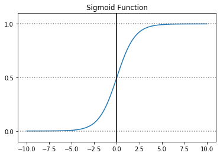

```python
z = np.linspace(-10, 10, 100)
get_sigmoid_plot(z)
```

## 將機率轉換為 $\hat{y} \in {\{0, 1\}}$

$$ \hat{y} = H(\sigma(z), prob) = \begin{cases} 1 & \quad \text{if } \sigma(z)\geq prob\\ 0 & \quad \text{otherwise}\\ \end{cases} $$

## 拆解羅吉斯回歸分類器的步驟

- 尋找 $h(X) = Xw$ 的 $w$
- 將 $h(X)$ 的輸出 $z$ 作為 Sigmoid 函數的輸入，得到 $\sigma(z)$
- 將 $\sigma(z)$ 作為 $H$ 的輸入，得到 $\hat{y}$

## 在迴歸問題中我們尋找 $h(X) = Xw$ 的 $w$ 是根據一個目標：讓成本函數 MSE 最小化

## 在分類問題中我們尋找 $h(X) = Xw$ 的 $w$ 則是依據：讓誤分類數最小化

$$J(h)_{test} = \sum^{n_{test}}\delta (\hat{y} \neq y_{test})$$

## 為了讓誤分類數最小化，得在尋找 $w$ 的過程中設計成本函數 $J$

$$ J(w) = \frac{1}{m}\big(-ylog\,(\sigma(Xw))-(1-y)log(1-\sigma(Xw))\big)\\ = \frac{1}{m}\big(-ylog(\sigma(z))-(1-y)log(1-\sigma(z))\big)\\ J(w) = \frac{1}{m}\big(-log(\sigma(z))\big) ,\text{ where y = 1} \\ J(w) = \frac{1}{m}\big(-log(1-\sigma(z))\big) ,\text{ where y = 0} $$

## 經過設計的成本函數 $J$ 稱為交叉熵（Cross-entropy）或 Log Loss

## 交叉熵（Cross-entropy）或 Log Loss 成本函數設計的巧妙處在於讓錯誤分類的成本趨近無限大

- 真實的 $y$ 為 1，$\sigma(z)$ 若離 0 比較近則成本將趨近無限大
- 真實的 $y$ 為 0，$\sigma(z)$ 若離 1 比較近則成本將趨近無限大

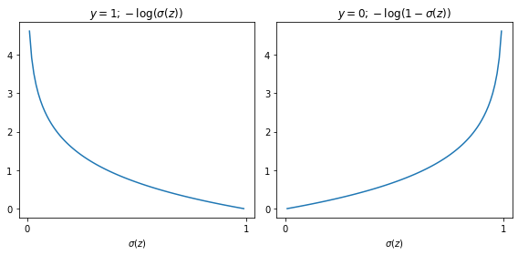

```python
x = np.arange(0.01, 1, 0.01)
get_cross_entropy_plot(x)
```

## 自訂 `get_cross_entropy()` 函數

```python
import numpy as np

def sigmoid(z):
    return(1 / (1 + np.exp(-z)))

def get_cross_entropy(X, y, w, epsilon=1e-8):
    m = y.size
    z = X.dot(w)
    h = sigmoid(z)
    y_reshaped = y.reshape(-1, 1)
    cost_y1 = -y_reshaped.T.dot(np.log(h+epsilon))
    cost_y0 = -((1-y_reshaped).T).dot(np.log(1-h+epsilon))
    cross_entropy = (cost_y1 + cost_y0) / m
    return cross_entropy[0, 0]
```

## 欲使用梯度遞減找到一組 $w$ 讓 $J(w)$ 最小化，得先計算梯度

$$ J(w) = -\frac{1}{m}\big(y\,log\,(\sigma(Xw))+(1-y)(\,log\,(1-\sigma(Xw))\big) \\ .\\ \text{...chain rules, the derivative of sigmoid function...} .\\ \frac{\mathrm \partial}{\mathrm \partial w} J(w) = \frac{1}{m}X^T\big(\sigma(Xw) - y\big) $$

Sources:

- http://math.stackexchange.com/questions/78575/derivative-of-sigmoid-function-sigma-x-frac11e-x
- https://stats.stackexchange.com/questions/278771/how-is-the-cost-function-from-logistic-regression-derivated

## 自訂 `get_grad()` 函數

```python
import numpy as np

def get_grad(X, y, w):
    m = y.size
    y_reshaped = y.reshape(-1, 1)
    z = X.dot(w)
    h = sigmoid(z)
    grad = (1/m)*(X.T.dot(h-y_reshaped))
    return grad[0, 0]
```

## 自訂 `adagrad()` 函數

```python
def adagrad(X, y, epochs, learning_rate, epsilon=1e-8):
    n = X.shape[1]
    w = np.random.rand(n, 1)
    j_history = []
    n_prints = 20
    interval = epochs // n_prints
    # Initiate sum of squared gradients
    ssg = np.zeros(n, dtype=float).reshape(-1, 1)
    for i in range(epochs):
        cross_entropy = get_cross_entropy(X, y, w)
        j_history.append(cross_entropy)
        grad = get_grad(X, y, w)
        # Use adaptive gradient to update w
        ssg += grad**2
        ada_grad = grad / (epsilon + ssg**0.5)
        w -= learning_rate*ada_grad
        if i % interval == 0:
            print("{} iterations: Cost: {}".format(i, cross_entropy))
    return w, j_history
```

## 如何操作羅吉斯迴歸分類器利用 `Age` 來預測乘客的生存與否

```python
import pandas as pd
from sklearn.model_selection import train_test_split
from sklearn.preprocessing import PolynomialFeatures

titanic = pd.read_csv("https://storage.googleapis.com/kaggle_datasets/Titanic-Machine-Learning-from-Disaster/train.csv")
titanic = titanic[titanic["Age"].notnull()]
poly = PolynomialFeatures(degree=1)
X = titanic["Age"].values.reshape(-1, 1)
X_poly = poly.fit_transform(X)
y = titanic["Survived"].values
X_train, X_validation, y_train, y_validation = train_test_split(X_poly, y, test_size=0.33, random_state=42)
```

```python
epochs = 200000
learning_rate = 1e-3
w, j_history = adagrad(X_train, y_train, epochs, learning_rate)
print("Weights: {}".format(w.ravel()))
```

```
0 iterations: Cost: 10.199470833467265
10000 iterations: Cost: 9.283136549994698
20000 iterations: Cost: 8.644262363208219
30000 iterations: Cost: 8.01620597531045
40000 iterations: Cost: 7.376059390316724
50000 iterations: Cost: 6.713766178417428
60000 iterations: Cost: 6.038725473061013
70000 iterations: Cost: 5.364348726573856
80000 iterations: Cost: 4.696378037227721
90000 iterations: Cost: 4.0520421041161025
100000 iterations: Cost: 3.4468203365983796
110000 iterations: Cost: 2.884991939132644
120000 iterations: Cost: 2.3708883258721665
130000 iterations: Cost: 1.9131132359934013
140000 iterations: Cost: 1.5243757713703212
150000 iterations: Cost: 1.2176813994628914
160000 iterations: Cost: 0.9985146880816026
170000 iterations: Cost: 0.8582060477554891
180000 iterations: Cost: 0.7765689545670346
190000 iterations: Cost: 0.731877785906235
Weights: [-0.56821532  0.01675151]
```

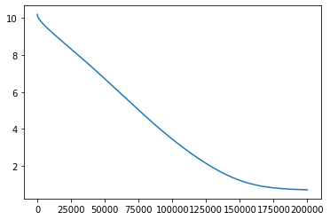

```python
import matplotlib.pyplot as plt

plt.plot(range(epochs), j_history)
plt.show()
```

## 使用階躍函數將機率轉換為 $\hat{y} \in {\{0, 1\}}$

```python
def step_function(prob, prob_threshold=0.5):
    if prob >= prob_threshold:
        return 1
    else:
        return 0

def get_y_pred(X_validation, w):
    h = X_validation.dot(w)
    z = sigmoid(h)
    z_ravel = z.ravel()
    vfunc = np.vectorize(step_function)
    y_pred = vfunc(z_ravel)
    y_pred = y_pred.astype(int)
    return y_pred
```

```python
y_pred = get_y_pred(X_validation, w)
n_tp_tn = (y_pred == y_validation).sum()
n_validations = y_validation.size
acc = n_tp_tn / n_validations
print("Accuracy score: {:.2f}%".format(acc*100))
```

```
Accuracy score: 55.51%
```

## 利用 DataFrame 觀察

```python
validation_df = pd.DataFrame()
validation_df["X_0"] = X_validation[:, 0].ravel()
validation_df["X_1(Age)"] = X_validation[:, 1].ravel()
validation_df["w_0"] = w[0, 0]
validation_df["w_1"] = w[1, 0]
validation_df["z"] = X_validation.dot(w).ravel()
validation_df["h"] = sigmoid(validation_df["z"].values)
validation_df["y_pred"] = np.where(validation_df["h"].values >= 0.48, 1, 0)
validation_df.head()
```

|  | X_0 | X_1(Age) | w_0 | w_1 | z | h | y_pred |
| --- | --- | --- | --- | --- | --- | --- | --- |
| 0 | 1.0 | 42.0 | -0.568215 | 0.016752 | 0.135348 | 0.533785 | 1 |
| 1 | 1.0 | 3.0 | -0.568215 | 0.016752 | -0.517961 | 0.373329 | 0 |
| 2 | 1.0 | 29.0 | -0.568215 | 0.016752 | -0.082421 | 0.479406 | 0 |
| 3 | 1.0 | 24.0 | -0.568215 | 0.016752 | -0.166179 | 0.458551 | 0 |
| 4 | 1.0 | 43.0 | -0.568215 | 0.016752 | 0.152100 | 0.537952 | 1 |

## 隨堂練習：操作羅吉斯迴歸分類器利用 `Age` 與 `Fare` 來預測乘客的生存與否

```python
import pandas as pd
from sklearn.model_selection import train_test_split
from sklearn.preprocessing import PolynomialFeatures

titanic = pd.read_csv("https://storage.googleapis.com/kaggle_datasets/Titanic-Machine-Learning-from-Disaster/train.csv")
titanic = titanic[titanic["Age"].notnull()]
poly = PolynomialFeatures(degree=1)
X = titanic[["Age", "Fare"]].values
X_poly = poly.fit_transform(X)
y = titanic["Survived"].values
X_train, X_validation, y_train, y_validation = train_test_split(X_poly, y, test_size=0.33, random_state=42)
```

## 隨堂練習：自訂 `get_cross_entropy()`

$$ J(w) = \frac{1}{m}\big(-ylog\,(\sigma(Xw))-(1-y)log(1-\sigma(Xw))\big)\\ = \frac{1}{m}\big(-ylog(\sigma(z))-(1-y)log(1-\sigma(z))\big)\\ $$

## 隨堂練習：自訂 `get_grad()`

$$ \frac{\mathrm \partial}{\mathrm \partial w} J(w) = \frac{1}{m}X^T\big(\sigma(Xw) - y\big) $$

## 隨堂練習：從上一個章節中自由選擇一個梯度遞減方法定義

## 隨堂練習：結合自訂的函數操作羅吉斯迴歸分類器利用 `Age` 與 `Fare` 來預測乘客的生存與否

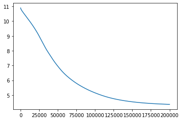

```python
import matplotlib.pyplot as plt

plt.plot(range(epochs), j_history)
plt.show()
```

```python
print(w)
print("Accuracy score: {:.2f}%".format(acc*100))
```

```
[[-0.58523894]
 [ 0.21768621]
 [-0.34008908]]
Accuracy score: 33.90%
```

## 決策樹分類器（Decision Tree Classifier）

## 什麼是決策樹分類器

> 決策樹分類器（Decision Tree Classifier）是廣泛使用的一種分類器，在給定變數中應用多個連續的 `if-else` 判斷不斷將觀測值一分為二，由於多個一分為二的過程中依照衡量指標，呈現一連串「決策」的「樹狀結構」，因此被稱為決策樹，除了廣泛應用於預測分類，亦有預測數值的應用（Decision Tree Regressor，回歸樹）。

## 文不如圖：決策樹分類器示意

Source: https://annalyzin.wordpress.com/2016/07/27/decision-trees-tutorial/

## 決策樹分類器的評估指標：熵（Entropy）與資訊增益（Information Gain）

$$ E = -\sum_{i=1}^N p_i \log_2 p_i \\ IG = E_O - \sum_{i=1}^q \frac{N_i}{N}E_i $$

## 熵（Entropy）是熱力學中用來衡量亂度（Degree of chaos）的指標

[figure not shown]

Source: https://heliosphan.org/shannon-entropy.html

## 以範例來理解評估指標

```python
import pandas as pd
from sklearn.model_selection import train_test_split

titanic = pd.read_csv("https://storage.googleapis.com/kaggle_datasets/Titanic-Machine-Learning-from-Disaster/train.csv")
X = titanic[["Pclass", "Sex"]].values
y = titanic["Survived"].values
X_train, X_validation, y_train, y_validation = train_test_split(X, y, test_size=0.33, random_state=42)
train_df = pd.DataFrame()
train_df["Pclass"] = X_train[:, 0]
train_df["Sex"] = X_train[:, 1]
train_df["Survived"] = y_train
train_df.head()
```

|  | Pclass | Sex | Survived |
| --- | --- | --- | --- |
| 0 | 1 | male | 0 |
| 1 | 3 | male | 0 |
| 2 | 2 | male | 0 |
| 3 | 3 | male | 0 |
| 4 | 3 | female | 0 |

## 該從哪一個變數開始切割？依據資訊增益（Information Gain）這個指標

## 計算 $y$ 的 Entropy

```python
import numpy as np

n_obs = train_df["Survived"].value_counts().sum()
n_dead = train_df["Survived"].value_counts()[0]
n_survived = train_df["Survived"].value_counts()[1]
p_dead = n_dead / n_obs
p_survived = n_survived / n_obs
E_y = -(p_dead*np.log2(p_dead) + p_survived*np.log2(p_survived))
print(E_y)
```

```
0.9525597111874977
```

## 計算 $Pclass$ 的 Entropy

```python
n_pclass_1 = train_df[(train_df["Pclass"] == 1)].shape[0]
n_pclass_1_dead = train_df[(train_df["Pclass"] == 1)]["Survived"].value_counts()[0]
n_pclass_1_survived = train_df[(train_df["Pclass"] == 1)]["Survived"].value_counts()[1]
n_pclass_2 = train_df[(train_df["Pclass"] == 2)].shape[0]
n_pclass_2_dead = train_df[(train_df["Pclass"] == 2)]["Survived"].value_counts()[0]
n_pclass_2_survived = train_df[(train_df["Pclass"] == 2)]["Survived"].value_counts()[1]
n_pclass_3 = train_df[(train_df["Pclass"] == 3)].shape[0]
n_pclass_3_dead = train_df[(train_df["Pclass"] == 3)]["Survived"].value_counts()[0]
n_pclass_3_survived = train_df[(train_df["Pclass"] == 3)]["Survived"].value_counts()[1]
```

```python
p_pclass_1_dead = n_pclass_1_dead / n_pclass_1
p_pclass_1_survived = n_pclass_1_survived / n_pclass_1
p_pclass_2_dead = n_pclass_2_dead / n_pclass_2
p_pclass_2_survived = n_pclass_2_survived / n_pclass_2
p_pclass_3_dead = n_pclass_3_dead / n_pclass_3
p_pclass_3_survived = n_pclass_3_survived / n_pclass_3
```

```python
E_pclass_1 = -(p_pclass_1_dead*np.log2(p_pclass_1_dead) + p_pclass_1_survived*np.log2(p_pclass_1_survived))
E_pclass_2 = -(p_pclass_2_dead*np.log2(p_pclass_2_dead) + p_pclass_2_survived*np.log2(p_pclass_2_survived))
E_pclass_3 = -(p_pclass_3_dead*np.log2(p_pclass_3_dead) + p_pclass_3_survived*np.log2(p_pclass_3_survived))
E_pclass = (n_pclass_1/n_obs)*E_pclass_1 +(n_pclass_2/n_obs)*E_pclass_2 + (n_pclass_3/n_obs)*E_pclass_3
print(E_pclass)
```

```
0.8797312234554393
```

## 計算 $Sex$ 的 Entropy

```python
n_female = train_df[(train_df["Sex"] == 'female')].shape[0]
n_female_dead = train_df[(train_df["Sex"] == 'female')]["Survived"].value_counts()[0]
n_female_survived = train_df[(train_df["Sex"] == 'female')]["Survived"].value_counts()[1]
n_male = train_df[(train_df["Sex"] == 'male')].shape[0]
n_male_dead = train_df[(train_df["Sex"] == 'male')]["Survived"].value_counts()[0]
n_male_survived = train_df[(train_df["Sex"] == 'male')]["Survived"].value_counts()[1]
```

```python
p_female_dead = n_female_dead / n_female
p_female_survived = n_female_survived / n_female
p_male_dead = n_male_dead / n_male
p_male_survived = n_male_survived / n_male
```

```python
E_female = -(p_female_dead * np.log2(p_female_dead) + p_female_survived * np.log2(p_female_survived))
E_male = -(p_male_dead * np.log2(p_male_dead) + p_male_survived * np.log2(p_male_survived))
E_sex = (n_female/n_obs)*E_female + (n_male/n_obs)*E_male
print(E_sex)
```

```
0.7492389685459823
```

## 計算 $IG_{Pclass}$ 與 $IG_{Sex}$

```python
IG_Pclass = E_y - E_pclass
IG_Sex = E_y - E_sex
print(IG_Pclass)
print(IG_Sex) # larger
```

```
0.07282848773205841
0.20332074264151545
```

## 因此我們先以性別分兩類，再以艙等分三類，共六類觀察存活與死亡數多寡，並依此預測驗證資料

## 將計算過程封裝為函數：計算目標向量的 Entropy

```python
def get_target_entropy(df, y_name, epsilon=1e-5):
    y = df[y_name].values
    unique_y = np.unique(y)
    n_obs = y.size
    entropy = 0
    for v in unique_y:
        n_obs_v = y[y == v].size
        p = n_obs_v / (n_obs + epsilon)
        entropy_i = p*np.log2(p + epsilon)
        entropy += entropy_i
    return -entropy
```

```python
get_target_entropy(train_df, "Survived")
```

```
0.9525308658190339
```

## 將計算過程封裝為函數：計算特徵矩陣中的變數 Entropy

```python
def get_attribute_entropy(df, y_name, x_name, epsilon=1e-5):
    x = df[x_name].values
    unique_x = np.unique(x)
    y = df[y_name].values
    unique_y = np.unique(y)
    n_obs = y.size
    attribute_entropy = 0
    for v_x in unique_x:
        entropy_i = 0
        for v_y in unique_y:
            n_obs_x_y = x[(x == v_x) & (y == v_y)].size
            n_obs_x = x[x == v_x].size
            p_x_y = n_obs_x_y / (n_obs_x + epsilon)
            entropy_i += p_x_y*np.log2(p_x_y)
        entropy_i = -entropy_i
        attribute_entropy += (n_obs_x / n_obs)*(entropy_i)
    return attribute_entropy
```

```python
E_pclass = get_attribute_entropy(train_df, "Survived", "Pclass")
E_sex = get_attribute_entropy(train_df, "Survived", "Sex")
print(E_pclass)
print(E_sex)
```

```
0.8797312495722829
0.7492389910114574
```

## 將計算過程封裝為函數：找出資訊增益值（Infomration Gain）較大的特徵

```python
def get_larger_ig(df, y_name, x_names):
    target_entropy = get_target_entropy(df, y_name)
    information_gains = []
    for x_name in x_names:
        attr_entropy = get_attribute_entropy(df, y_name, x_name)
        ig = target_entropy - attr_entropy
        information_gains.append(ig)
    information_gains = np.array(information_gains)
    max_ig_idx = np.argmax(information_gains)
    return x_names[max_ig_idx]
```

```python
get_larger_ig(train_df, "Survived", ["Pclass", "Sex"])
```

```
'Sex'
```

## 預測

```python
freq_table = pd.crosstab(index=train_df["Survived"], columns=[train_df["Sex"], train_df["Pclass"]])
freq_table
```

| Sex Pclass Survived | female 1 | female 2 | female 3 | male 1 | male 2 | male 3 |
| --- | --- | --- | --- | --- | --- | --- |
| 0 | 3 | 1 | 53 | 52 | 63 | 202 |
| 1 | 56 | 47 | 46 | 24 | 14 | 35 |

```python
def get_y_pred(X, freq_table):
    n_obs = X.shape[0]
    y_pred = np.zeros(n_obs, dtype=int)
    for i in range(n_obs):
        if X[i, 1] == 'female' and X[i, 0] == 1:
            y_pred[i] = freq_table.loc[:, "female"].loc[:, 1].idxmax()
        elif X[i, 1] == 'female' and X[i, 0] == 2:
            y_pred[i] = freq_table.loc[:, "female"].loc[:, 2].idxmax()
        elif X[i, 1] == 'female' and X[i, 0] == 3:
            y_pred[i] = freq_table.loc[:, "female"].loc[:, 3].idxmax()
        elif X[i, 1] == 'male' and X[i, 0] == 1:
            y_pred[i] = freq_table.loc[:, "male"].loc[:, 1].idxmax()
        elif X[i, 1] == 'male' and X[i, 0] == 2:
            y_pred[i] = freq_table.loc[:, "male"].loc[:, 2].idxmax()
        elif X[i, 1] == 'male' and X[i, 0] == 3:
            y_pred[i] = freq_table.loc[:, "male"].loc[:, 3].idxmax()
    return y_pred
```

```python
y_pred = get_y_pred(X_validation, freq_table)
n_tp_tn = (y_pred == y_validation).sum()
n_validations = y_validation.size
acc = n_tp_tn / n_validations
print("Accuracy score: {:.2f}%".format(acc*100))
```

```
Accuracy score: 77.29%
```

## 決策樹愈多層愈有可能產生過度配適

```python
freq_table = pd.crosstab(index=train_df["Survived"], columns=train_df["Sex"])
freq_table
```

| Sex Survived | female | male |
| --- | --- | --- |
| 0 | 57 | 317 |
| 1 | 149 | 73 |

```python
def get_y_pred(X, freq_table):
    n_obs = X.shape[0]
    y_pred = np.zeros(n_obs, dtype=int)
    for i in range(n_obs):
        if X[i, 1] == 'female':
            y_pred[i] = freq_table.loc[:, "female"].idxmax()
        elif X[i, 1] == 'male':
            y_pred[i] = freq_table.loc[:, "male"].idxmax()
    return y_pred
```

```python
y_pred = get_y_pred(X_validation, freq_table)
n_tp_tn = (y_pred == y_validation).sum()
n_validations = y_validation.size
acc = n_tp_tn / n_validations
print("Accuracy score: {:.2f}%".format(acc*100))
```

```
Accuracy score: 79.66%
```

## 使用 `sklearn.DecisionTreeClassifier()` 創建決策樹分類器

```python
import pandas as pd
from sklearn.model_selection import train_test_split
from sklearn.preprocessing import LabelEncoder

titanic = pd.read_csv("https://storage.googleapis.com/kaggle_datasets/Titanic-Machine-Learning-from-Disaster/train.csv")
le = LabelEncoder()
sex_encoded = le.fit_transform(titanic["Sex"].values)
X = np.concatenate([titanic["Pclass"].values.reshape(-1, 1), sex_encoded.reshape(-1, 1)], axis=1)
y = titanic["Survived"].values
X_train, X_validation, y_train, y_validation = train_test_split(X, y, test_size=0.33, random_state=42)
```

```python
from sklearn.tree import DecisionTreeClassifier

dtc = DecisionTreeClassifier(criterion="entropy", max_depth=2)
dtc.fit(X_train, y_train)
y_pred = dtc.predict(X_validation)
n_tp_tn = (y_pred == y_validation).sum()
n_validations = y_validation.size
acc = n_tp_tn / n_validations
print("Accuracy score: {:.2f}%".format(acc*100))
```

```
Accuracy score: 77.29%
```

```python
def get_decision_boundaries(X, X_train, y_train, dtc, fig_title):
    x_min, x_max = X[:, 0].min() - 1, X[:, 0].max() + 1
    y_min, y_max = X[:, 1].min() - 1, X[:, 1].max() + 1
    xx, yy = np.meshgrid(np.arange(x_min, x_max, 0.1),
                         np.arange(y_min, y_max, 0.1))
    f, axarr = plt.subplots(1, 1)
    Z = dtc.predict(np.c_[xx.ravel(), yy.ravel()])
    Z = Z.reshape(xx.shape)
    axarr.contourf(xx, yy, Z, alpha=0.4)
    axarr.scatter(X[:, 0], X[:, 1], c=y, s=20, edgecolor='k')
    axarr.set_title(fig_title)
    plt.show()
```

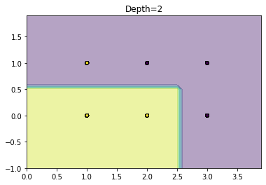

```python
get_decision_boundaries(X, X_train, y_train, dtc, "Depth=2")
```

```python
from sklearn.tree import DecisionTreeClassifier

dtc = DecisionTreeClassifier(criterion="entropy", max_depth=1)
dtc.fit(X_train, y_train)
y_pred = dtc.predict(X_validation)
n_tp_tn = (y_pred == y_validation).sum()
n_validations = y_validation.size
acc = n_tp_tn / n_validations
print("Accuracy score: {:.2f}%".format(acc*100))
```

```
Accuracy score: 79.66%
```

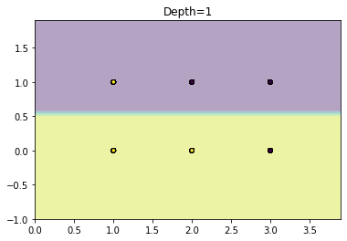

```python
get_decision_boundaries(X, X_train, y_train, dtc, "Depth=1")
```

## 如果決策樹分類器希望納入數值變數呢？

## 常用方法有兩種

- 將數值變數分組為類別變數
- 將單一數值看作一個類別進行比較 Entropy，並且遞迴執行（實作複雜，我們暫時避開）

## 納入數值變數的決策樹分類器在多個分支後更容易過度配適

```python
import pandas as pd
from sklearn.model_selection import train_test_split

titanic = pd.read_csv("https://storage.googleapis.com/kaggle_datasets/Titanic-Machine-Learning-from-Disaster/train.csv")
titanic = titanic[titanic["Age"].notnull()]
X = titanic[["Age", "Fare"]].values
y = titanic["Survived"].values
X_train, X_validation, y_train, y_validation = train_test_split(X, y, test_size=0.33, random_state=42)
```

```python
from itertools import product
import matplotlib.pyplot as plt
from sklearn.tree import DecisionTreeClassifier

def get_decision_boundaries(X, X_train, y_train):
    x_min, x_max = X[:, 0].min() - 1, X[:, 0].max() + 1
    y_min, y_max = X[:, 1].min() - 1, X[:, 1].max() + 1
    xx, yy = np.meshgrid(np.arange(x_min, x_max, 0.1),
                         np.arange(y_min, y_max, 0.1))
    f, axarr = plt.subplots(2, 4, sharex='col', sharey='row', figsize=(16, 6))
    for idx, depth in zip(product([0, 1, 2, 3], [0, 1, 2, 3]),
                              [1, 2, 3, 4, 5, 6, 7, 8]):
        dtc = DecisionTreeClassifier(criterion="entropy", max_depth=depth)
        dtc.fit(X_train, y_train)
        Z = dtc.predict(np.c_[xx.ravel(), yy.ravel()])
        Z = Z.reshape(xx.shape)
        axarr[idx[0], idx[1]].contourf(xx, yy, Z, alpha=0.4)
        axarr[idx[0], idx[1]].scatter(X[:, 0], X[:, 1], c=y, s=20, edgecolor='k')
        axarr[idx[0], idx[1]].set_title("Depth={}".format(depth))
    plt.show()
```

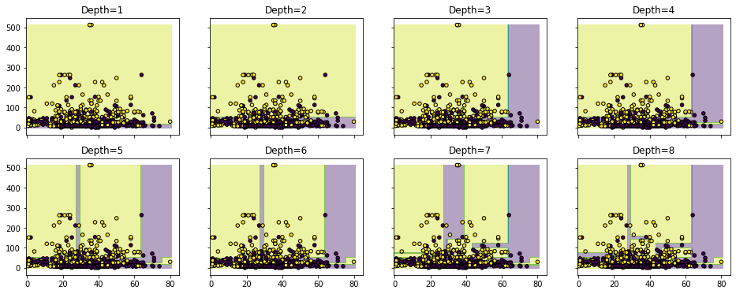

```python
get_decision_boundaries(X, X_train, y_train)
```

```python
import pandas as pd
from sklearn.model_selection import train_test_split
from sklearn.tree import DecisionTreeClassifier

titanic = pd.read_csv("https://storage.googleapis.com/kaggle_datasets/Titanic-Machine-Learning-from-Disaster/train.csv")
titanic = titanic[titanic["Age"].notnull()]
X = titanic[["Age", "Fare"]].values
y = titanic["Survived"].values
X_train, X_validation, y_train, y_validation = train_test_split(X, y, test_size=0.33, random_state=42)
dtc = DecisionTreeClassifier(criterion="entropy", max_depth=30)
dtc.fit(X_train, y_train)
y_pred = dtc.predict(X_train)
n_tp_tn = (y_pred == y_train).sum()
n_train = y_train.size
acc_train = n_tp_tn / n_train
y_pred = dtc.predict(X_validation)
n_tp_tn = (y_pred == y_validation).sum()
n_validations = y_validation.size
acc_validation = n_tp_tn / n_validations
```

```python
print("Accuracy score of Train: {:.2f}%".format(acc_train*100))
print("Accuracy score of Validation: {:.2f}%".format(acc_validation*100))
```

```
Accuracy score of Train: 98.12%
Accuracy score of Validation: 59.32%
```

## 可以透過集成學習（Ensemble Learning）降低分類器的變異（Variance），而決策樹分類器的集成學習就是隨機森林分類器

## 隨機森林分類器（Random Forest Classifier）

## 什麼是隨機森林分類器

> 隨機森林分類器是一種常用的集成學習（Ensemble Learning），它依賴於簡單估計決策樹分類器聚合，多個決策樹的投票多數決可能比單一決策樹分類器的預測效果更好。

## 什麼是集成學習

> 藉由聚合多個強分類器（過度配適的分類器）或弱分類器（Under-fitting 的分類器）來達到提升最後的預測與分類結果，常見用來聚合分類器的架構有 Bagging、Boosting 與 Stacking；隨機森林分類器即為應用 Bagging 架構與決策樹分類器的集成學習，Bagging 架構指的是將樣本重複抽樣，產生多個子資料集後，依序建立多個模型，最後再將所有模型的結果聚合在一起，在分類問題中用投票法決定分類結果。

```python
import pandas as pd
from sklearn.model_selection import train_test_split
from sklearn.tree import DecisionTreeClassifier

titanic = pd.read_csv("https://storage.googleapis.com/kaggle_datasets/Titanic-Machine-Learning-from-Disaster/train.csv")
titanic = titanic[titanic["Age"].notnull()]
X = titanic[["Age", "Fare"]].values
y = titanic["Survived"].values
X_train, X_validation, y_train, y_validation = train_test_split(X, y, test_size=0.33, random_state=42)
dtc = DecisionTreeClassifier(criterion="entropy", max_depth=30)
dtc.fit(X_train, y_train)
y_pred = dtc.predict(X_train)
n_tp_tn = (y_pred == y_train).sum()
n_train = y_train.size
acc_train = n_tp_tn / n_train
y_pred = dtc.predict(X_validation)
n_tp_tn = (y_pred == y_validation).sum()
n_validations = y_validation.size
acc_validation = n_tp_tn / n_validations
print("Accuracy score of Train: {:.2f}%".format(acc_train*100))
print("Accuracy score of Validation: {:.2f}%".format(acc_validation*100))
```

```
Accuracy score of Train: 98.12%
Accuracy score of Validation: 61.44%
```

```python
n_samples = X_train.shape[0] // 2
n_trees = 100
y_preds = np.zeros((y_validation.size, n_trees), dtype=int)
for i in range(n_trees):
    subset_indices = np.random.choice(range(n_samples), n_samples)
    X_train_subset, y_train_subset = X_train[subset_indices, :], y_train[subset_indices]
    dtc = DecisionTreeClassifier(criterion="entropy", max_depth=30)
    dtc.fit(X_train_subset, y_train_subset)
    y_pred = dtc.predict(X_validation)
    y_preds[:, i] = y_pred
```

```python
print(y_preds)
```

```
[[0 1 1 ... 1 1 0]
 [1 0 1 ... 1 1 1]
 [0 0 1 ... 1 1 1]
 ...
 [0 0 1 ... 1 1 0]
 [0 1 1 ... 1 1 1]
 [0 0 0 ... 0 0 0]]
```

```python
y_pred = np.zeros(y_validation.size, dtype=int)
for i in range(y_preds.shape[0]):
    vote = np.bincount(y_preds[i, :]).argmax()
    y_pred[i] = vote
print(y_pred)
```

```
[1 1 1 1 0 0 1 0 1 0 1 1 1 0 1 0 0 1 1 0 0 0 1 1 0 1 1 0 0 0 0 0 1 0 0 0 1
 0 0 0 1 0 1 0 1 0 1 0 0 0 1 1 1 1 0 0 1 1 0 0 0 0 0 1 0 0 1 0 0 0 1 1 0 0
 0 0 0 0 0 1 0 1 0 0 0 0 0 0 0 0 0 1 0 0 1 0 0 1 1 0 1 0 0 1 1 1 0 1 0 0 1
 0 1 0 0 1 1 1 1 0 1 0 1 0 0 0 0 0 0 0 0 1 0 0 1 0 0 0 0 0 0 0 0 1 0 0 0 1
 0 0 0 0 0 0 1 1 0 1 1 1 0 1 1 1 1 0 1 0 0 0 0 0 0 1 0 0 0 0 0 0 1 1 1 1 0
 0 0 1 0 0 1 1 0 0 1 1 0 1 1 0 0 1 0 1 1 0 1 0 0 1 0 0 1 0 0 0 0 0 0 0 1 0
 0 0 0 0 1 0 1 1 0 1 1 0 1 0]
```

```python
n_tp_tn = (y_pred == y_validation).sum()
n_validations = y_validation.size
acc = n_tp_tn / n_validations
print("Accuracy score: {:.2f}%".format(acc*100))
```

```
Accuracy score: 62.29%
```

## 使用 `sklearn.ensemble.RandomForestClassifier()` 創建隨機森林分類器

```python
from sklearn.ensemble import RandomForestClassifier

n_trees = 100
rf = RandomForestClassifier(n_estimators=n_trees, criterion='entropy', max_depth=30)
rf.fit(X_train, y_train)
y_pred = rf.predict(X_validation)
n_tp_tn = (y_pred == y_validation).sum()
n_validations = y_validation.size
acc = n_tp_tn / n_validations
print("Accuracy score: {:.2f}%".format(acc*100))
```

```
Accuracy score: 64.41%
```

```python
from itertools import product
import matplotlib.pyplot as plt
from sklearn.ensemble import RandomForestClassifier

def get_decision_boundaries(X, X_train, y_train):
    x_min, x_max = X[:, 0].min() - 1, X[:, 0].max() + 1
    y_min, y_max = X[:, 1].min() - 1, X[:, 1].max() + 1
    xx, yy = np.meshgrid(np.arange(x_min, x_max, 0.1),
                         np.arange(y_min, y_max, 0.1))
    f, axarr = plt.subplots(2, 2, sharex='col', sharey='row', figsize=(10, 8))
    for idx, n_trees in zip(product([0, 1], [0, 1]),
                            [25, 50, 75, 100]):
        rf = RandomForestClassifier(criterion="entropy", max_depth=30, n_estimators=n_trees)
        rf.fit(X_train, y_train)
        Z = rf.predict(np.c_[xx.ravel(), yy.ravel()])
        Z = Z.reshape(xx.shape)
        axarr[idx[0], idx[1]].contourf(xx, yy, Z, alpha=0.4)
        axarr[idx[0], idx[1]].scatter(X[:, 0], X[:, 1], c=y, s=20, edgecolor='k')
        axarr[idx[0], idx[1]].set_title("No. of Trees: {}".format(n_trees))
    plt.show()
```

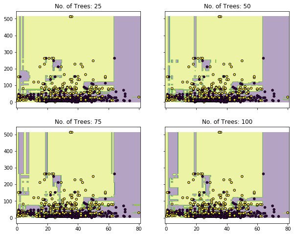

```python
get_decision_boundaries(X, X_train, y_train)
```

## 二元至多元（One vs. All）

## 到目前為止我們都只有面對二元分類問題

- `breast_cancer`: malignant vs. benign
- `nba_players`: Forward vs. Guard
- `titanic`: Dead vs. Survived

## 延展二元分類問題為多元分類問題常用的技巧稱為 One vs. All（或稱 One vs. Rest）

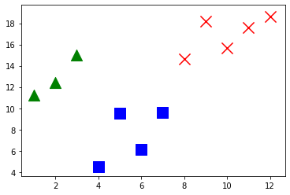

```python
get_demo_plot()
```

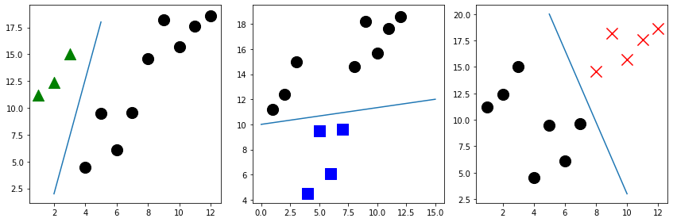

```python
get_demo_plot()
```

## 比較三種分類機率，取最大者

$$y \in {\{0, 1, 2\}}$$$$h^{0}(X) = P(y = 0 \mid X, w)$$$$h^{1}(X) = P(y = 1 \mid X, w)$$$$h^{2}(X) = P(y = 2 \mid X, w)$$$$\text{prediction:}\;\;max(h^{0}(X), h^{1}(X), h^{2}(X))$$

## 以 digit recognizer 為例：如何延展二元分類為多元分類（`n = 10`）

```python
import numpy as np
import pandas as pd

digits = pd.read_csv("https://kaggle-getting-started.s3-ap-northeast-1.amazonaws.com/mnist/train.csv")
X = digits.drop(labels="label", axis=1).values
y = digits["label"].values
X_train, X_validation, y_train, y_validation = train_test_split(X, y, test_size=0.33, random_state=42)
print(np.unique(y).size)
```

```
10
```

```python
from sklearn.linear_model import LogisticRegression

def y_recoder(y, i):
    y_recoded = np.where(y == i, 0, 1)
    return y_recoded

y_probs = np.zeros((y_validation.size, np.unique(y).size), dtype=float)
for i in np.unique(y):
    random_indices = np.random.choice(range(y_train.size), size=1000)
    X_train_subset = X_train[random_indices, :]
    y_train_subset = y_train[random_indices]
    y_train_subset_recoded = y_recoder(y_train_subset, i)
    lr = LogisticRegression(solver='lbfgs', C=10000)
    lr.fit(X_train_subset, y_train_subset_recoded)
    i_prob = lr.predict_proba(X_validation)[:, 0]
    y_probs[:, i] = i_prob
```

```python
print(y_probs[:10, :])
```

```
[[0.00000000e+00 0.00000000e+00 0.00000000e+00 0.00000000e+00
  0.00000000e+00 0.00000000e+00 0.00000000e+00 0.00000000e+00
  1.00000000e+00 0.00000000e+00]
 [0.00000000e+00 1.00000000e+00 0.00000000e+00 0.00000000e+00
  0.00000000e+00 0.00000000e+00 4.79264628e-10 0.00000000e+00
  0.00000000e+00 0.00000000e+00]
 [0.00000000e+00 0.00000000e+00 0.00000000e+00 0.00000000e+00
  0.00000000e+00 0.00000000e+00 0.00000000e+00 1.34762645e-10
  0.00000000e+00 6.44908571e-11]
 [0.00000000e+00 0.00000000e+00 0.00000000e+00 0.00000000e+00
  6.73163747e-11 0.00000000e+00 0.00000000e+00 0.00000000e+00
  0.00000000e+00 1.00000000e+00]
 [0.00000000e+00 0.00000000e+00 0.00000000e+00 0.00000000e+00
  0.00000000e+00 0.00000000e+00 0.00000000e+00 0.00000000e+00
  1.00000000e+00 0.00000000e+00]
 [1.32071100e-07 0.00000000e+00 1.00000000e+00 0.00000000e+00
  0.00000000e+00 8.58982465e-01 0.00000000e+00 0.00000000e+00
  1.00000000e+00 0.00000000e+00]
 [0.00000000e+00 0.00000000e+00 1.00000000e+00 0.00000000e+00
  0.00000000e+00 0.00000000e+00 0.00000000e+00 0.00000000e+00
  9.99979967e-01 0.00000000e+00]
 [0.00000000e+00 0.00000000e+00 4.63332276e-08 0.00000000e+00
  0.00000000e+00 0.00000000e+00 0.00000000e+00 0.00000000e+00
  0.00000000e+00 0.00000000e+00]
 [0.00000000e+00 0.00000000e+00 0.00000000e+00 0.00000000e+00
  0.00000000e+00 0.00000000e+00 0.00000000e+00 1.00000000e+00
  0.00000000e+00 0.00000000e+00]
 [0.00000000e+00 1.00000000e+00 1.11823883e-11 0.00000000e+00
  0.00000000e+00 0.00000000e+00 2.39586129e-13 0.00000000e+00
  0.00000000e+00 0.00000000e+00]]
```

```python
y_pred = np.zeros(y_validation.size, dtype=int)
for i in range(y_probs.shape[0]):
    max_idx = y_probs[i, :].argmax()
    y_pred[i] = max_idx
print(y_pred[:10])
```

```
[8 1 7 9 8 2 2 2 7 1]
```

```python
def plot_first_10(arr_set):
    for i, k in enumerate(range(1, 11)):
        plt.subplot(2, 5, k)
        plt.imshow(arr_set.reshape(arr_set.shape[0], 28, 28)[i], cmap = "gray")
        plt.xticks([]), plt.yticks([])
    plt.tight_layout()
    plt.show()
```

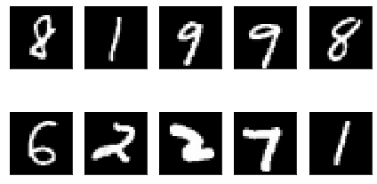

```python
plot_first_10(X_validation)
```